# Informe III

# Base de datos

## Flujos de comercio internacional

Recurrimos al COMTRADE de la ONU, donde tenemos datos a nivel mensual de las transacciones entre países según bien. De este modo podemos recoger el agregado anual de las transacciones (Importaciones/Exportaciones/ReExportaciones). Una API nos da acceso a esta información, de modo que la solicitud de información está asociada a las capacidades de la API.

### Países

Conrespecto a los países a estudiar, si nos concentramos en América Latina y el Caribe, la base no observa las Islas Malvinas, las Islas Georgias del Sur y Sandwich del Sur, la Isla San Martín Francés, y Puerto Rico, posiblemente porque las incluye dentro de otros países. Pero por ejemplo las islas virgenes estadounidenses si tienen cabida dentro de las observaciones.

### Bienes

La API automáticamente usa el sistema harmonizado actualizado. De modo que se tiene que trabajar la consistencia entre observaciones que trabajan con distintas codificaciones de HS. Con una llave premium se puede homoegeneizar la muestra a H0 con la función `ct_get_bulk`, o bien intentar usar las tablas de correlación oficiales entre sistemas harmonizados.

## Modelo de gravitacional

Las denominaciones ISO3 del dataset gravitacional[^1] difieren de las del UNCOMTRADE, mejorar la unión de estas bases a nivel exportación de bien por par de países es un desafío próximo.

## Bienes de Uso Dual

Centrandonos en los bienes de wassenaar recurrimos a la tabla de correlación de la Unión Europea para identificar los bienes de uso dual del regimen de control según su codificación de aduanas (HS).

### Países Firmantes

Se recurrió a las actas de las asambleas del tratado de Wassenaar para identificar a los firmantes y el año en que se adscriben.

## clasificación por Industrias

Con el objetivo de evaluar la heterogeneidad de los efectos según industria usamos las tablas de correspondencia entre el sistema harmonizado y el ISIC revisión 3 para clasificar las transacciones en un industria específica.

| Grupo ISIC rev 3 | Industria |
| --- | --- |
| A | Agricultura, Cazería y Forestales |
| B | Pesca |
| C | Minería y extracción por canteras |
| D | Manufacturas |
| E | Electricidad, Gas y Agua |
| F* | Construcción |
| G* | Artículos de uso doméstico y ventas al por mayor, y Reparación de vehículos motorizados |
| H* | Hoteles y restaurantes |
| I* | Transporte, Almacenaje y Comunicación |
| J* | Intermediación financiera |
| K | Inmobiliario, Alquiler, y Negocios |
| L* | Administración pública y defenza |
| M* | Educación |
| N* | Salud y trabajo social |
| O | Otras actividades sociales, comunitarias o de servicios personales |
| P* | Trabajo doméstico |
| Q | Cuerpos y organizaciones extra-territoriales |
| . | * no están presentes en la tabla de correlación |

# Resultados preliminares

Busquemos el efecto promedio de firmar el acuerdo en las exportaciones. La variable `wamem_o` es indicador de si el país de origen está adscrito al acuerdo de wassenaar para el año en que se produce la transacción. Sin distinguir entre bienes de uso dual y otras exportaciones el coeficiente que estimamos en el siguiente modelo indica la correlación presente entre estar adscrito y un incremento de nivel en las exportaciones. Todo esto controlando por covariables propias de un estudio de comercio internacional.

```
## NOTE: 68,311 observations removed because of NA values (RHS: 68,311).
```

```
##                            gravity_pois
## Dependent Var.:                   value
##
## wamem_o                0.5895* (0.2663)
## wamem_d                 0.1934 (0.2112)
## log(gdp_wdi_const_o)   -0.6057 (0.4559)
## log(gdp_wdi_const_d)  1.055*** (0.1838)
## log(distance)            -1.011 (1.210)
## common_language         0.4567 (0.4097)
## contiguity               2.024. (1.175)
## agree_pta            0.3135*** (0.0135)
## wamem_o x wamem_d     -0.3480. (0.2109)
## Fixed-Effects:       ------------------
## iso3_o                              Yes
## year                                Yes
## cmd_hs                              Yes
## iso3_d                              Yes
## ____________________ __________________
## S.E.: Clustered              by: iso3_o
## Observations                  2,175,877
## Squared Cor.                    0.66231
## Pseudo R2                       0.83221
## BIC                            1.21e+13
## ---
## Signif. codes: 0 '***' 0.001 '**' 0.01 '*' 0.05 '.' 0.1 ' ' 1
```

### Estudio de eventos

Hacemos un análisis idéntico al anterior. Pero ahora trabajamos la posible heterogeneidad de este efecto en el tiempo. Vemos los efectos que tiene estar adscrito comparando los cambios en nivel teniendo como baseline el año antes de la firma. De este modo, estudiando una ventana de tiempo 5 años antes de firmar y 5 años después estimamos 10 coeficientes para conocer la trayectoria con respecto a introducirse a este régimen de control.

$$log(T_{ijnt}) =
\sum_{l=-5}^{-2}\beta_l\textbf{i}(t-\tau_i=l)+\sum_{l=0}^{5}\beta_l\textbf{i}(t-\tau_i=l)+\gamma_1was_{jt}+
\beta_{-6}\textbf{i}(t-\tau_i<-5)+
\beta_{-6}\textbf{i}(t-\tau_i>-5)\\
\alpha_i + \alpha_j +\alpha_n+ \alpha_t +\\
\gamma_3log(GDP_{it})+\gamma_4log(GDP_{jt})+\gamma_4log(Dist_{ijt})+\Gamma
X_{ijt}+\epsilon_{ijt}$$
$\textbf{i}()$ es una función indicador. Mientras que $\tau_i$ es el año en el que el país $i$ firma el acurdo de wassenaar. Encontrar efectos positivos y significativos para los coeficientes posteriores a adscribir al acuerdo describirían al trayectoria de ajuste. Por otro lado, encontrar trayectorias previas al acuerdo puede dar indicios de que hay cuestiones de selección de base que hace que un país firme o no, y que estas diferencias tambien están afectando los resultados de la trayectoria post-firma. Naturalemente, esperamos encontrar estas cuestiones de base. No encontrar o encontrar leves trayectorias previas, da indicios de que las trayectorais posteriores que encontramos sí obedecen a efectos psudo-exógenos del régimen de control.

```
## NOTE: 127,702 observations removed because of NA values (RHS: 127,702).
```

```
##                             gravity_pois
## Dependent Var.:                    value
##
## bmenos                  -0.0876 (0.0834)
## bm5                  -0.1576*** (0.0477)
## bm4                    -0.1268* (0.0611)
## bm3                     -0.0952 (0.0754)
## bm2                      0.0165 (0.0160)
## b0                    0.0994*** (0.0281)
## b1                     0.1322** (0.0441)
## b2                    0.1315*** (0.0177)
## b3                    0.3271*** (0.0921)
## b4                       0.2702 (0.1651)
## b5                     0.3011** (0.1033)
## bmas                    0.2663. (0.1430)
## wamem_d                 -0.1243 (0.1768)
## log(gdp_wdi_const_o)    -0.1493 (0.5116)
## log(gdp_wdi_const_d)   1.559*** (0.1052)
## log(distance)             -1.481 (1.230)
## common_language          0.3591 (0.2750)
## contiguity                 1.478 (1.065)
## agree_pta             0.4609*** (0.0881)
## Fixed-Effects:       -------------------
## iso3_o                               Yes
## year                                 Yes
## cmd_hs                               Yes
## iso3_d                               Yes
## ____________________ ___________________
## S.E.: Clustered               by: iso3_o
## Observations                   3,572,696
## Squared Cor.                     0.96767
## Pseudo R2                        0.89362
## BIC                             3.65e+13
## ---
## Signif. codes: 0 '***' 0.001 '**' 0.01 '*' 0.05 '.' 0.1 ' ' 1
```

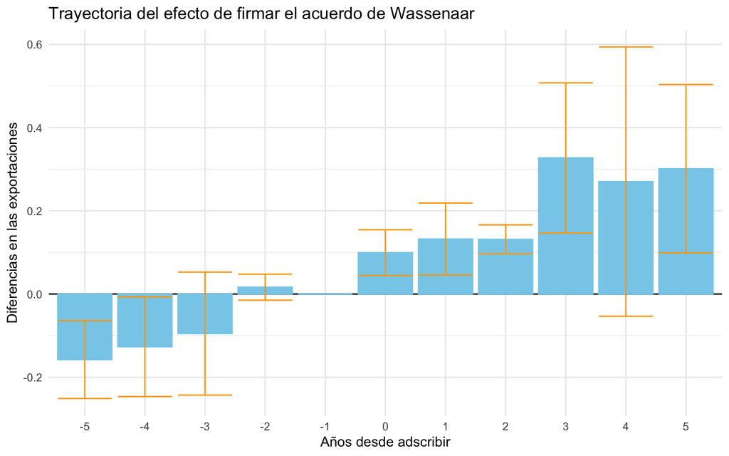

### Industrias

```
## NOTE: 2,690 observations removed because of NA values (RHS: 2,690).
```

```
## NOTE: 87 observations removed because of NA values (RHS: 87).
```

```
## NOTE: 300 observations removed because of NA values (RHS: 300).
```

```
## NOTE: 54,209 observations removed because of NA values (RHS: 54,209).
```

```
## NOTE: 2 observations removed because of NA values (RHS: 2).
```

```
## The variables 'common_language', 'contiguity' and 'agree_pta' have been removed because of collinearity (see $collin.var).
```

```
## NOTE: 7 observations removed because of NA values (RHS: 7).
```

```
## NOTE: 95 observations removed because of NA values (RHS: 95).
```

```
## NOTE: 488 observations removed because of NA values (RHS: 488).
```

|  | cil | ciu | coeficiente | des.est. | observaciones | industria |
| --- | --- | --- | --- | --- | --- | --- |
| wamem_o | 0.2989886 | 1.9252273 | 1.1121079 | 0.0000138 | 78550 | A |
| wamem_o1 | 1.4996373 | 3.3310197 | 2.4153285 | 0.0001919 | 4441 | B |
| wamem_o2 | -0.6283911 | 0.9292058 | 0.1504073 | 0.0000120 | 15075 | C |
| wamem_o3 | -0.2486262 | 1.2116897 | 0.4815318 | 0.0000046 | 1835479 | D |
| wamem_o4 | 0.7896280 | 1.9639273 | 1.3767777 | 0.0001684 | 78 | E |
| wamem_o5 | -0.5246914 | 0.5643900 | 0.0198493 | 0.0011100 | 976 | K |
| wamem_o6 | -0.5110479 | 0.6278708 | 0.0584114 | 0.0002564 | 4530 | O |
| wamem_o7 | -1.1579738 | 0.2389235 | -0.4595251 | 0.0000494 | 13677 | Q |

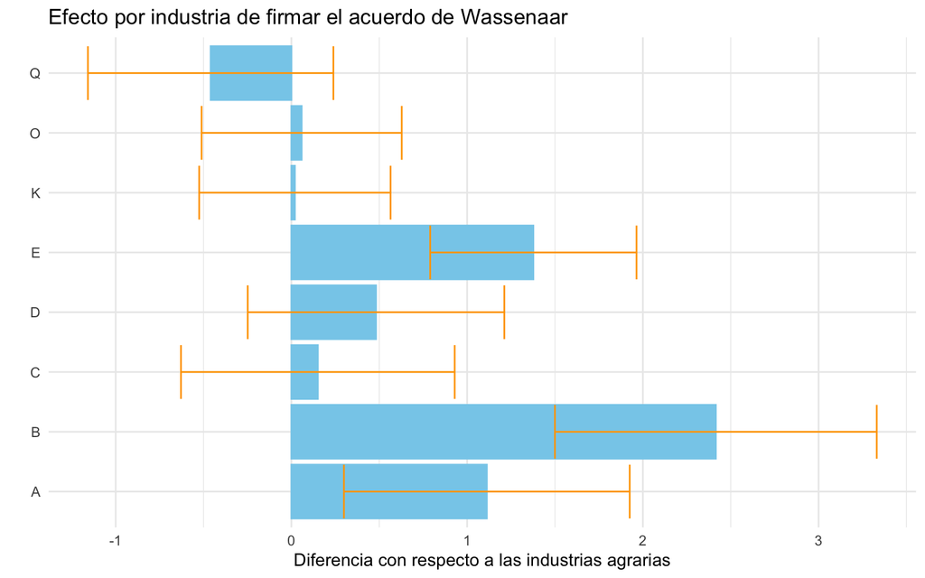

[^1]: Tamara Gurevich and Peter Herman, (2018). The Dynamic Gravity Dataset: 1948-2016. USITC Working Paper 2018-02-A.